# Part II - Flight Delays Exploration and Visualisation

## by Gladys Dalla

## Investigation Overview

- In this investigations, I focused on touch down or arrival delays, how airlines, airports and routes are affected by it,the distribution of delay reasons and the changes over the past decade.

## Dataset Overview

- The data consists of flight arrival and departure details for all commercial flights within the USA in the year 2007 and 1997 of approximately 12 million records combined. The attributes included Identification information, Flight information, Time information, Flight duration information, On-ground information and Delay reasons.
- The data had to be filtered, to remove columns not needed, incomplete records, and records of cancelled flights, which were out of the scope of this project. Check the wrangling file for this.

## Distribution of Arrival Delay

- There are delayed arrivals as well as earlier arrivals and the most of them are between -42 to 48 min differ of the scheduled time.

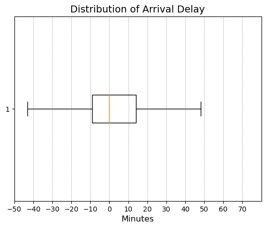

## The extent of Arrival delay distributed among flights

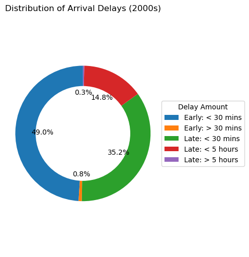

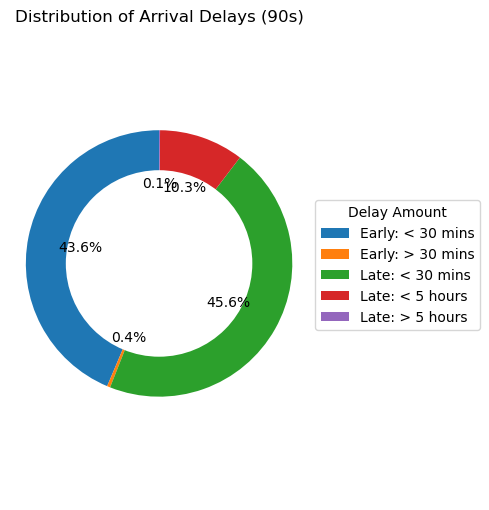

## Airport Analysis

1. Among the airports; Atlanta Intl(ATL) Airport has the highest inbound and outbound traffic while Downtown(MKC) Airport has the least. Nantucket Memorial(ACK) airport experiences the highest delays while Mercedita (PSE) Airport experiences the least delays.

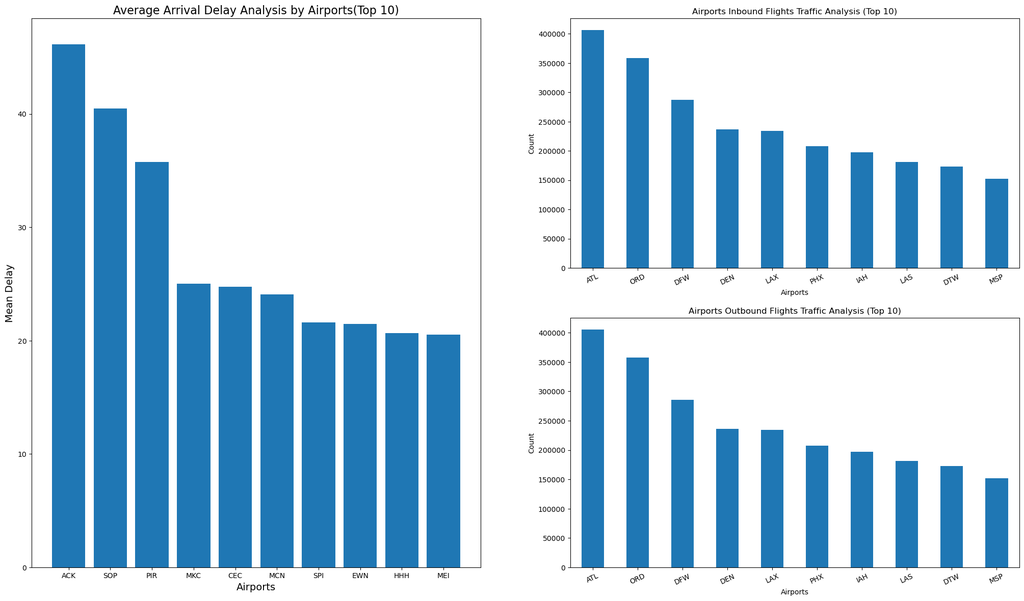

```
Bottom 10 Inbound - Outbound Flights:
```

|  | Inbound | Outbound |
| --- | --- | --- |
| DLG | 171 | 171 |
| MTH | 126 | 124 |
| BJI | 114 | 114 |
| ADK | 89 | 97 |
| GST | 86 | 88 |
| EAU | 66 | 65 |
| ISO | 8 | 7 |
| PIR | 4 | 3 |
| GLH | 2 | 2 |
| MKC | 1 | 1 |

```
Bottom 10 Airport Delays:
```

[output not shown]

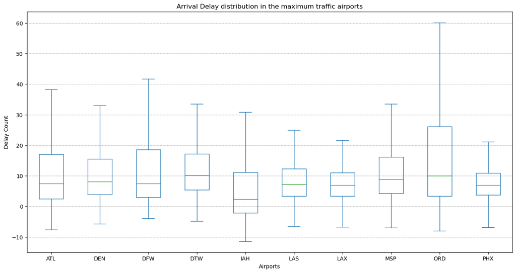

## Airline Analysis

1. Among the airlines; Southwest Airlines tops the list with the highest volume of flight numbers in the 2000s. This is an increase from the 90s of 47%. Delta Air which toped in the 90s has a reduced volume in the 2000s with a drop of 48%.

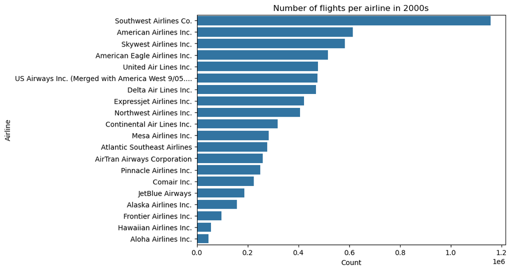

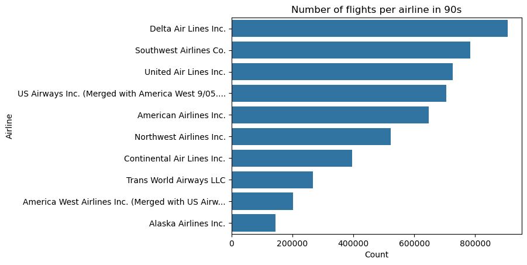

1. Among the airlines; Atlantic Southeast Airlines(EV) experiences the highest amount of arrival delays with an average of 17 min with Southwest Airlines experiencing the least amount of arrival delays with an average of 6 minutes. Aloha Airlines and Hawaiian Airlines are the only airlines with no delays as they arrive earlier than expected.

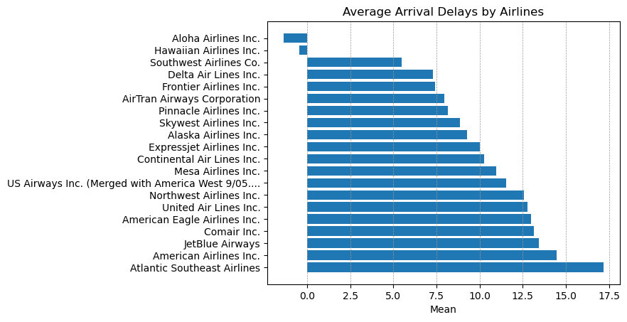

1. Among the top 10 busiest airlines; the highest delays are experienced by American Airlines (AA) which is the 2nd highest in number of flights overall. The least number of delays are experienced by Southwest Airlines (WN) which tops the list of highest number of flights overall. This is in contrast with each other and shows the superiority of SouthWest Airlines.

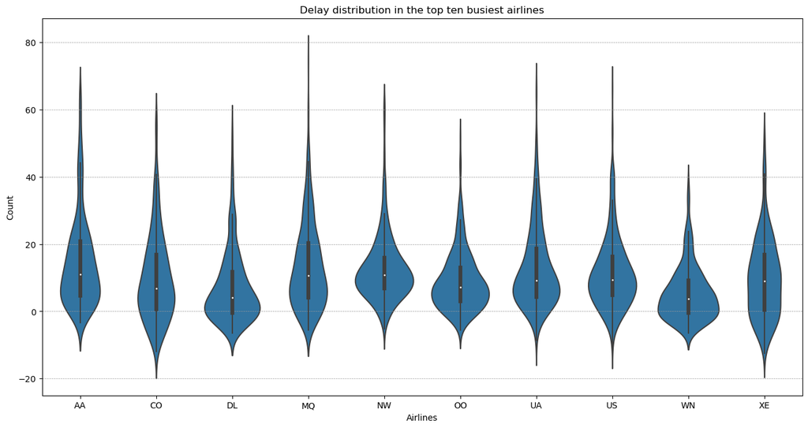

## Route Analysis

1. Among the routes; Kahului(OGG) - Honolulu International(HNL) route is the highest travelled. Ontario International(ONT) to Washington Dulles International(IAD) route experiences the highest delays while McCarran International (LAS) Airport to Central Illinois Regional(BMI) Airport experiences the least delays.

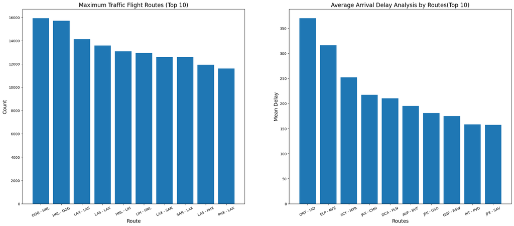

1. Among the busiest routes; Maximum delay experienced by the busiest routes is 20 minutes with United Airlines. This shows the busiest routes don't have high number of delays with the airlines that cover these routes. McCarran International(LAS) to Los Angeles International(LAX) route(to and fro) experiences the highest delays among the airlines that fly this route while LIH to HNL is the route that experiences less delays(to and fro) amongst the airlines that fly this route

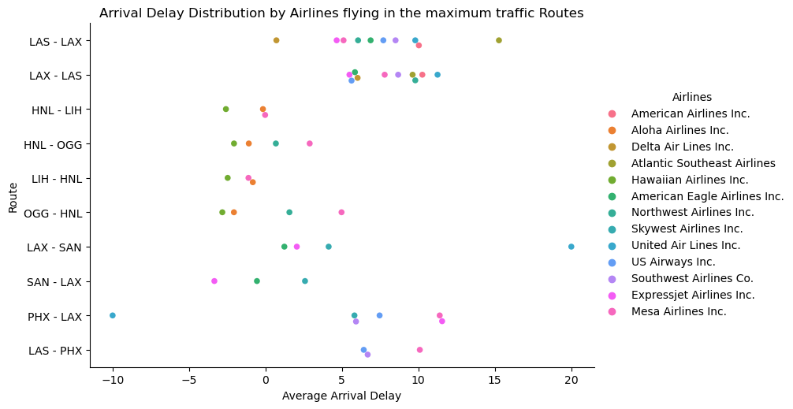

## Delay reasons Analysis

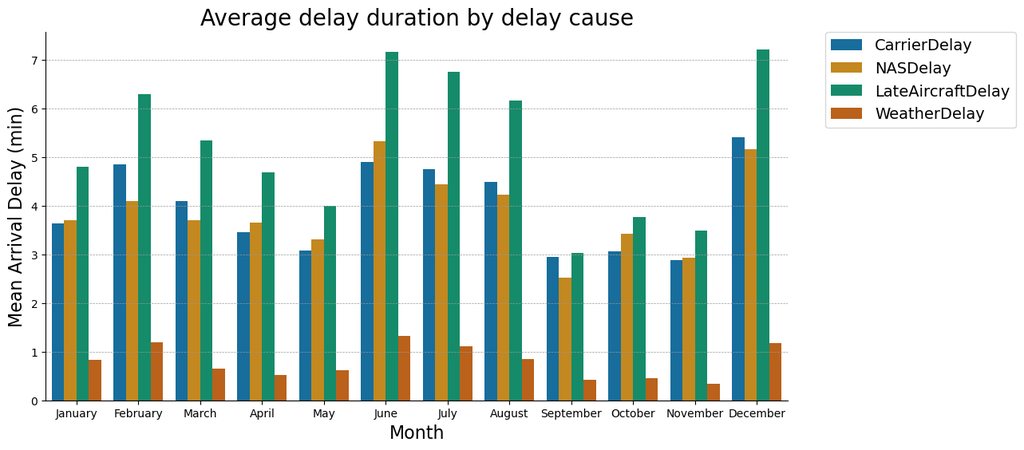